# END-TO-END ANALYTICS FOR CANCER MORTALITY

```python
#All imports

import pandas as pd
from snowflake.snowpark import Session
import seaborn as sns
import scipy.stats as stats
import matplotlib.pyplot as plt

from statsmodels.stats.multicomp import pairwise_tukeyhsd
from statsmodels.multivariate.pca import PCA

from sklearn.preprocessing import  OneHotEncoder, MinMaxScaler, StandardScaler
from sklearn.compose import ColumnTransformer
from sklearn.model_selection import train_test_split
from sklearn.pipeline import Pipeline
from sklearn.linear_model import LogisticRegression

from sklearn.ensemble import RandomForestClassifier
from sklearn.metrics import accuracy_score
from sklearn.inspection import permutation_importance
from sklearn.model_selection import learning_curve

pd.set_option("display.max_rows", 10)
```

# Data Import

**Format File -> Variable**  
BLS regions -> regions  
Cancer deaths -> deaths  
Socail determinants -> determinants  
State demographics -> demographics

```python
deaths = pd.read_csv("./cancer_deaths.csv")
regions = pd.read_csv("./bls_regions.csv")
determinants = pd.read_csv("./social_determinants.csv")
demographics = pd.read_csv("./state_demographics.csv")
```

# DATA Wrangling/Cleaning

**Converted deaths per 100,000 to death per 1000 (keeping a standard scale)**

```python
#since we have deaths rate per 100,000  converting this data to  deaths per 1000
numerical_column_deaths = deaths.select_dtypes(include="number").columns
deaths[numerical_column_deaths] = deaths[numerical_column_deaths] * 1000 / 100000

#Displaying deths per 1000
deaths.head()
```

|  | State | Cancer Death Rate.Total | Cancer Death Rate.Breast | Cancer Death Rate.Colorectal | Cancer Death Rate.Lung |
| --- | --- | --- | --- | --- | --- |
| 0 | Alabama | 2.142 | 0.274 | 0.194 | 0.664 |
| 1 | Alaska | 1.281 | 0.178 | 0.119 | 0.366 |
| 2 | Arizona | 1.656 | 0.233 | 0.149 | 0.423 |
| 3 | Arkansas | 2.239 | 0.279 | 0.212 | 0.733 |
| 4 | California | 1.509 | 0.230 | 0.140 | 0.345 |

**Pivoted Social determinant data to columns for clubbing with other cancer data and better analysis**

```python
# We need to pivot social determinant as all the data is saved in columns and we need to get state wise social determinant data:

pivot_df_determinant = determinants.pivot_table(
    index = "State",
    columns = "Variable",
    values = "Count",
    aggfunc="mean"
).fillna(0)
pivot_df_determinant.head()
```

| Variable State | Cigarette Use.Adult.Smokers | Cigarette Use.Adult.Tried to Quit | Social Determinants.Consumed 1 or More Fruits per Day | Social Determinants.Consumed 1 or More Vegetables per Day | Social Determinants.Had a Mammogram in Past 2 Years | Social Determinants.Healthy Weight (BMI 18.5 to <25) | Social Determinants.No Leisure Time Physical Activity | Social Determinants.Received at Least One Recommended CRC Test |
| --- | --- | --- | --- | --- | --- | --- | --- | --- |
| Alabama | 590423.0 | 426231.0 | 2723159.0 | 3989278.0 | 3547141.0 | 1271143.0 | 1462065.0 | 3401437.0 |
| Alaska | 82005.0 | 53397.0 | 424633.0 | 597714.0 | 458369.0 | 213417.0 | 153279.0 | 456169.0 |
| Arizona | 661867.0 | 370069.0 | 4176477.0 | 5606778.0 | 4805809.0 | 2181208.0 | 1523270.0 | 4412477.0 |
| Arkansas | 388531.0 | 217744.0 | 1644292.0 | 2397173.0 | 2068917.0 | 755893.0 | 978745.0 | 1927375.0 |
| California | 2644835.0 | 1459787.0 | 25225386.0 | 30642123.0 | 26530148.0 | 13047614.0 | 9054253.0 | 24316007.0 |

**Merged all the data state wise keeping same scale population/1000**

```python
#Since we already converted deaths per 1000 now we are merging other data state wise after this we will convert that per 1000
cancer_df_merged = pd.merge(regions, pivot_df_determinant, on="State" ,how="inner")
cancer_df_merged = pd.merge(cancer_df_merged, demographics, on="State" ,how="inner")

cancer_data_numerical_columns = cancer_df_merged.select_dtypes(include="number").columns

#Converting each column value to rate per 1000
for column in cancer_data_numerical_columns:
    if column != 'State Demographics.Population':
        cancer_df_merged[column] = (cancer_df_merged[column] * 1000 )/ cancer_df_merged['State Demographics.Population']

#Merging cancer deaths and rest of the cancer data
cancer_df_merged = pd.merge(cancer_df_merged, deaths, on="State" ,how="inner")
cancer_df_merged.head()
```

|  | State | Region | Cigarette Use.Adult.Smokers | Cigarette Use.Adult.Tried to Quit | Social Determinants.Consumed 1 or More Fruits per Day | Social Determinants.Consumed 1 or More Vegetables per Day | Social Determinants.Had a Mammogram in Past 2 Years | Social Determinants.Healthy Weight (BMI 18.5 to <25) | Social Determinants.No Leisure Time Physical Activity | Social Determinants.Received at Least One Recommended CRC Test | ... | State Demographics.Income.Persons Below Poverty Level | State Demographics.Miscellaneous.Language Other than English at Home | State Demographics.Miscellaneous.Under 65 Years Witout Health Insurance | State Demographics.Miscellaneous.Under 66 Years With a Disability | State Demographics.Sales.Accommodation and Food Services Sales | State Demographics.Sales.Retail Sales | Cancer Death Rate.Total | Cancer Death Rate.Breast | Cancer Death Rate.Colorectal | Cancer Death Rate.Lung |
| --- | --- | --- | --- | --- | --- | --- | --- | --- | --- | --- | --- | --- | --- | --- | --- | --- | --- | --- | --- | --- | --- |
| 0 | Alabama | Southeast | 117.513976 | 84.834262 | 541.999957 | 794.000094 | 706.000005 | 253.000082 | 290.999962 | 677.000023 | ... | 154.999951 | 53.000042 | 117.000071 | 115.999928 | 1507.969999 | 11656.391892 | 2.142 | 0.274 | 0.194 | 0.664 |
| 1 | Alaska | West | 111.816207 | 72.808366 | 578.999470 | 815.000457 | 624.999489 | 291.000299 | 209.000383 | 621.999725 | ... | 100.999331 | 161.000067 | 138.999524 | 89.000274 | 3028.855004 | 14281.979190 | 1.281 | 0.178 | 0.119 | 0.366 |
| 2 | Arizona | West | 92.549369 | 51.747032 | 583.999977 | 784.000060 | 671.999952 | 304.999985 | 213.000010 | 617.000037 | ... | 135.000032 | 270.999994 | 135.999962 | 87.000046 | 1957.160188 | 11845.978929 | 1.656 | 0.233 | 0.149 | 0.423 |
| 3 | Arkansas | Southwest | 129.014745 | 72.303591 | 545.999965 | 795.999965 | 687.000004 | 251.000158 | 324.999900 | 639.999880 | ... | 162.000037 | 74.999900 | 108.999961 | 125.999992 | 1430.260559 | 12224.792497 | 2.239 | 0.279 | 0.212 | 0.733 |
| 4 | California | West | 66.893118 | 36.920906 | 637.999993 | 775.000004 | 671.000009 | 330.000010 | 228.999998 | 614.999996 | ... | 117.999992 | 442.000011 | 89.000004 | 67.000001 | 2297.280078 | 12185.688290 | 1.509 | 0.230 | 0.140 | 0.345 |

5 rows × 31 columns

**Snowflake Connection and data upload**  
Now here we are pushing the data to Snowflake to do analysis using SQL and to further do EDA on power BI.

```python
# Write Pandas DataFrame to Snowflake table (auto-creates schema)
#Creating session config
conn = {
"user" : "SHIPATEL302",
"password" : "Patelshivani@123",
"account" :  "GZHMWWI-YMC90175",
"role" : "ACCOUNTADMIN",
"warehouse" : "SNOWFLAKE_LEARNING_WH",
"database" : "CANCER",
"schema" : "PUBLIC"
}

# Create session
session = Session.builder.configs(conn).create()
#Write to table
session.write_pandas(cancer_df_merged, 'cancer_deaths_complete', auto_create_table=True, overwrite=True)
```

```
<snowflake.snowpark.table.Table at 0x2b27ea14b90>
```

# Average death by region plot

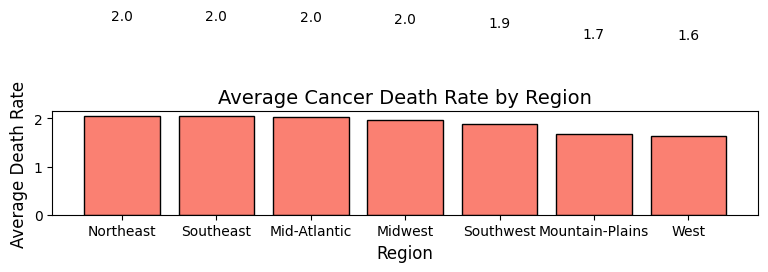

```python
 #Group by Region and calculate average
region_avg = cancer_df_merged.groupby("Region")["Cancer Death Rate.Total"].mean().reset_index()

# Sort descending by death rate
region_avg = region_avg.sort_values(by="Cancer Death Rate.Total", ascending=False)

# Plot
plt.figure(figsize=(8,6))
plt.bar(region_avg["Region"], region_avg["Cancer Death Rate.Total"], color="salmon", edgecolor="black")

plt.title("Average Cancer Death Rate by Region", fontsize=14)
plt.xlabel("Region", fontsize=12)
plt.ylabel("Average Death Rate", fontsize=12)

# Add labels on bars
for i, val in enumerate(region_avg["Cancer Death Rate.Total"]):
    plt.text(i, val + 2, round(val, 1), ha="center", fontsize=10)

plt.tight_layout()
plt.show()
```

# Top 10 States by Average Fruit & Vegetable Consumption

```
C:\Users\shivani patel\AppData\Local\Temp\ipykernel_22376\2692707606.py:3: SettingWithCopyWarning:
A value is trying to be set on a copy of a slice from a DataFrame.
Try using .loc[row_indexer,col_indexer] = value instead

See the caveats in the documentation: https://pandas.pydata.org/pandas-docs/stable/user_guide/indexing.html#returning-a-view-versus-a-copy
  top10_regions["food_consumption"] = food_consumption
```

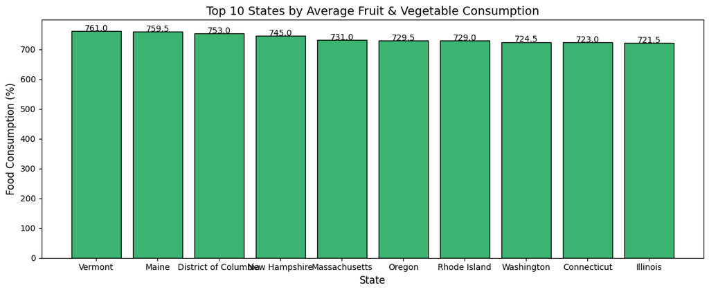

```python
food_consumption = (cancer_df_merged["Social Determinants.Consumed 1 or More Fruits per Day"] + cancer_df_merged["Social Determinants.Consumed 1 or More Vegetables per Day"])/2
top10_regions = cancer_df_merged[["State", "Region"]]
top10_regions["food_consumption"] = food_consumption
top10 = top10_regions.sort_values(
    by="food_consumption", ascending=False
).head(10)
plt.figure(figsize=(12,5))
plt.bar(top10["State"], top10["food_consumption"], color="mediumseagreen", edgecolor="black")

plt.title("Top 10 States by Average Fruit & Vegetable Consumption", fontsize=14)
plt.xlabel("State", fontsize=12)
plt.ylabel("Food Consumption (%)", fontsize=12)

# Show values on top of bars
for i, val in enumerate(top10["food_consumption"]):
    plt.text(i, val + 0.5, round(val, 1), ha="center", fontsize=10)

plt.tight_layout()
plt.show()
```

# Top Average food consumption by region plot

```
C:\Users\shivani patel\AppData\Local\Temp\ipykernel_22376\2968305752.py:15: UserWarning: Tight layout not applied. The left and right margins cannot be made large enough to accommodate all Axes decorations.
  plt.tight_layout()
```

[figure not shown]

```python
top10_regions.sort_values(
    by="food_consumption", ascending=False
).head(3)
plt.figure(figsize=(8,6))
top10 = top10.head(7)
plt.bar(top10["Region"], top10["food_consumption"], color="seagreen", edgecolor="black")

plt.title("Average Fruit & Vegetable Consumption by Region", fontsize=14)
plt.xlabel("Region", fontsize=12)
plt.ylabel("Food Consumption (%)", fontsize=12)

for i, val in enumerate(top10["food_consumption"]):
    plt.text(i, val + 0.5, round(val, 1), ha="center", fontsize=9)

plt.tight_layout()
plt.show()
```

Also we found that most people in northeast region eat healthy food.

We will further do statistical test to prove or findings in EDA.

# Analysis Correlation map using seaborn

**Smoking and age > 65 is highly correlated to cancer deaths**  
**Eating fruits and vegetables are negetively correlated to cancer deaths**

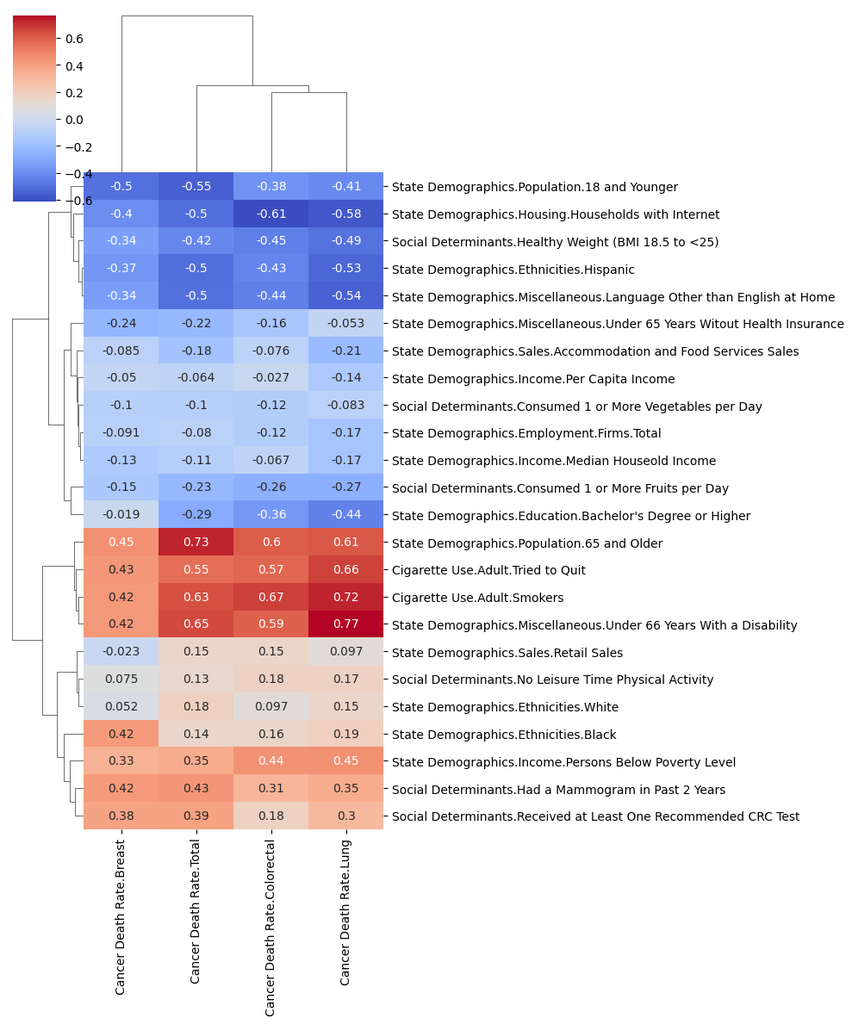

```python
numeric_data = cancer_df_merged.select_dtypes(include='number')
numeric_data = numeric_data.drop(columns=['State Demographics.Population'])
selected_cols = [
    "Cancer Death Rate.Total",
    "Cancer Death Rate.Breast",
    "Cancer Death Rate.Colorectal",
    "Cancer Death Rate.Lung",
]
filtered_df = cancer_df_merged[selected_cols]


# Before Revision:
# 2.2 Remove those same four variables from the rows
other_cols_df = numeric_data.drop(columns=selected_cols)



# 2.3 Correlate other variables (rows) with selected cancer columns (columns)
non_square_corr_df = pd.DataFrame()

for col in selected_cols:
    non_square_corr_df[col] = other_cols_df.corrwith(filtered_df[col])

# 2.4 : Now plot using seaborn's clustermap
sns.clustermap(non_square_corr_df, cmap="coolwarm", annot=True, figsize=(10, 12))
```

# ANOVA TEST

Performed ANOVA test to find if Region is statistically significant in causing cancer deaths

```python
# Perform an ANOVA test to see if there is a statistical significance between region and cancer death

deaths = [
    cancer_df_merged.query(f"Region == '{region}'")["Cancer Death Rate.Total"]
    for region in cancer_df_merged["Region"].dropna().unique()
]


result = stats.f_oneway(*deaths)


# - The :.1f formats the F statistic to 1 decimal place
# - The :.1e formats the p-value in scientific notation with 1 decimal place
print(f"F stat: {result.statistic:.1f}, p-value: {result.pvalue:.3f}")
if (result.pvalue < 0.05):
    print(f"P value is {result.pvalue:.3f} which is way less than 0.05 therefore significant relationship is found between region and cancer death")
```

```
F stat: 3.5, p-value: 0.006
P value is 0.006 which is way less than 0.05 therefore significant relationship is found between region and cancer death
```

# Tukey HSD Test

Since we found significant statistical relation between regions and deaths using ANOVA we furrther performed Tuky test to find which regions determine cancer deaths.

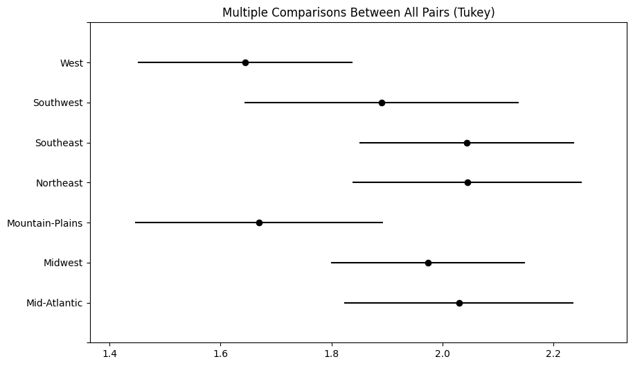

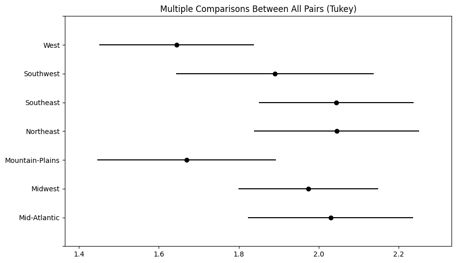

```python
# 1.2 Since significant difference was found between regions, perform Tukey's HSD using statsmodels


# Create a DataFrame with cancer death rates and region
tukey_data = cancer_df_merged[["Cancer Death Rate.Total", "Region"]].dropna()

# Perform Tukey's HSD test
tukey_result = pairwise_tukeyhsd(
    endog=tukey_data["Cancer Death Rate.Total"],
    groups=tukey_data["Region"],
    alpha=0.05
)

tukey_result.plot_simultaneous()
# Plot the results
```

We found cancer is more prevalant in Northeast and south east regions, whereas west and mountain plains are relatevely less affected by cancer deaths.

# PCA (Principal Component Analysis)

** We performed PCA converging the factors into two components:**

```python
#4.1 Drop non numeric cols
numeric_data = cancer_df_merged.select_dtypes(include='number')
numeric_data = numeric_data.drop(columns=['State Demographics.Population'])

result = PCA(

    # We're only using the numeric feature columns
    numeric_data ,
    # demean=True means that the mean will be subtracted from each feature
    # This centers the data around zero
    demean=True,
    # standardize=False means that we are NOT scaling each feature to have unit variance
    # If True, each feature would be divided by its standard deviation
    # R's `prcomp()` would use both center = TRUE and scale. = TRUE for standardization
    standardize=True,
    # We won't get into the math behind this parameter.  Just know that setting it to
    # False is the more typical use case for our purposes.
    normalize=False,
    # ncomp=2 specifies that we want to keep only the first 2 principal components
    # These will be the 2 directions that capture the most variance in the data
    ncomp=2,
)
print(result)
print(result.loadings)
```

```
Principal Component Analysis(nobs: 51, nvar: 28, transformation: Standardize (Correlation), normalization: False, number of components: 2, SVD)
                                                      comp_0    comp_1
Cigarette Use.Adult.Smokers                         0.300494 -0.078503
Cigarette Use.Adult.Tried to Quit                   0.290037 -0.091752
Social Determinants.Consumed 1 or More Fruits p... -0.111808  0.155776
Social Determinants.Consumed 1 or More Vegetabl... -0.028459  0.097215
Social Determinants.Had a Mammogram in Past 2 Y...  0.075903  0.279503
...                                                      ...       ...
State Demographics.Sales.Retail Sales               0.023373  0.119557
Cancer Death Rate.Total                             0.304292  0.182235
Cancer Death Rate.Breast                            0.242536  0.181728
Cancer Death Rate.Colorectal                        0.299348  0.114436
Cancer Death Rate.Lung                              0.322189  0.102431

[28 rows x 2 columns]
```

Further we plotted Region on the two components to find how different region contributes to the two principal components.

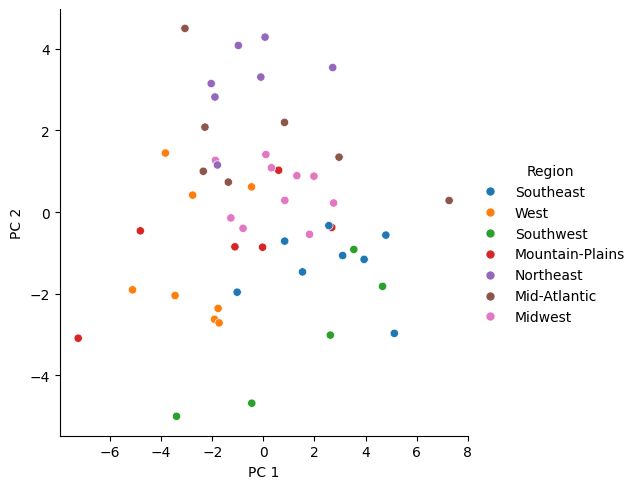

```python
# Prepare the data for plotting
plot_data = (
    result.scores.rename(
        columns={
            # Rename the first principal component for better readability
            "comp_0": "PC 1",
            # Rename the second principal component for better readability
            "comp_1": "PC 2",
        }
    )
    # Add the Region column from the original dataset for coloring points
    .assign(Region=cancer_df_merged['Region'])
)

# Create a scatter plot using seaborn
# - relplot creates a relational plot (scatter plot in this case)
# - x and y specify which columns to use for the x and y axes
#   (the first two principal components)
# - hue colors the points based on the Species column
sns.relplot(plot_data, x="PC 1", y="PC 2", hue="Region")
```

# MACHINE LEARNING

**Process & Pipeline**  
**Prepping data -> Segrigated Numerical Cols -> Split Data in Train and Test -> One hot encoding -> Normalization -> ML model Training -> Prediction** Converted cancer rate to 0 and 1 to predict cancer mortality.  
divided Train and test data in 80:20 ratio.  
Used Logistic regression model for prediction using test data.

```python
#MACHINE LEARNING



#dropping insignificant columns
cancer_data_significant = cancer_df_merged.drop(columns=['State Demographics.Population', 'State'])
#Taking out result column
result = cancer_df_merged["Cancer Death Rate.Total"]
mean_result = result.mean()
#Changing result column in category where 0= no cancer, 1= cancer:
result = (result > mean_result).astype(int)
#[0,1,1,1,0]


#dropping result columns
selected_cols = [
    "Cancer Death Rate.Total",
    "Cancer Death Rate.Breast",
    "Cancer Death Rate.Colorectal",
    "Cancer Death Rate.Lung",
]
cancer_data_significant = cancer_data_significant.drop(columns=selected_cols)
cancer_data_significant.info()
numerical_cols = cancer_data_significant.select_dtypes(include='number').columns

categorical_col = ["Region"]
#Min max scalar transforms to normalize data betwwen 0 to 1
preprocess = ColumnTransformer(
    transformers= [
        ("num", MinMaxScaler(), numerical_cols),
        ("cat", OneHotEncoder(handle_unknown="ignore"), categorical_col)

    ]
)
X_train, X_test, y_train, y_test = train_test_split(cancer_data_significant, result, test_size=0.2, random_state=42, stratify=result)
#print(X_train.shape, y_train.shape)
model = Pipeline([
    ("prep", preprocess),
    ("clf", LogisticRegression(max_iter=1000))
])

model.fit(X_train,y_train)
y_pred = model.predict(X_test)
print("actual", y_test.to_list())
print("predicted" ,y_pred)

res = 0
for i,j  in zip(y_test.to_list(), y_pred):
    if i == j:
        res += 1

print("Accuracy", res * 100/len(y_pred))
```

```
<class 'pandas.core.frame.DataFrame'>
RangeIndex: 51 entries, 0 to 50
Data columns (total 25 columns):
 #   Column                                                                   Non-Null Count  Dtype
---  ------                                                                   --------------  -----
 0   Region                                                                   51 non-null     object
 1   Cigarette Use.Adult.Smokers                                              51 non-null     float64
 2   Cigarette Use.Adult.Tried to Quit                                        51 non-null     float64
 3   Social Determinants.Consumed 1 or More Fruits per Day                    51 non-null     float64
 4   Social Determinants.Consumed 1 or More Vegetables per Day                51 non-null     float64
 5   Social Determinants.Had a Mammogram in Past 2 Years                      51 non-null     float64
 6   Social Determinants.Healthy Weight (BMI 18.5 to <25)                     51 non-null     float64
 7   Social Determinants.No Leisure Time Physical Activity                    51 non-null     float64
 8   Social Determinants.Received at Least One Recommended CRC Test           51 non-null     float64
 9   State Demographics.Population.65 and Older                               51 non-null     float64
```

[output cut: 20 more lines]

```python
#Prediction using Random Forest model & Feature Importance
```

```python
pipeline = Pipeline(steps=[
    ("preprocessor", preprocess),
    ("classifier", RandomForestClassifier(n_estimators=1000, random_state=40))
])

# Fit model
pipeline.fit(X_train, y_train)

# Predict
y_pred = pipeline.predict(X_test)

# Evaluate
print("Accuracy:", accuracy_score(y_test, y_pred))

r = permutation_importance(pipeline, X_test, y_test, n_repeats=5, random_state=42)
perm_df = pd.DataFrame({"feature":X_test.columns, "importance":r.importances_mean}).sort_values("importance", ascending=False)
perm_df.head(10)
```

```
Accuracy: 0.8181818181818182
```

|  | feature | importance |
| --- | --- | --- |
| 20 | State Demographics.Miscellaneous.Language Othe... | 0.145455 |
| 22 | State Demographics.Miscellaneous.Under 66 Year... | 0.109091 |
| 3 | Social Determinants.Consumed 1 or More Fruits ... | 0.090909 |
| 6 | Social Determinants.Healthy Weight (BMI 18.5 t... | 0.072727 |
| 1 | Cigarette Use.Adult.Smokers | 0.072727 |
| 14 | State Demographics.Ethnicities.Hispanic | 0.072727 |
| 11 | State Demographics.Education.Bachelor's Degree... | 0.018182 |
| 19 | State Demographics.Income.Persons Below Povert... | 0.018182 |
| 16 | State Demographics.Housing.Households with Int... | 0.018182 |
| 8 | Social Determinants.Received at Least One Reco... | 0.000000 |